# Matriz varianza - covarianza.

UNIVERSIDAD NACIONAL ROSARIO CASTELLANOS. ESTADISTICA MULTIVARIADA. PROFESOR: Rene Chabele. GRUPO: 403 Carlos Daniel Gallegos Garcia. Construccion de la Matriz Varianza - Covarianza en R.

Objetivo: Construir la *matriz de varianza - covarianza* apartir de *rendimientos diarios* calculados sobre los *precio de cierre ajustados* desde el 1 de enero de 2024 para las siguientes empresas:

- Amazon (AMAZON)
- Appel (AAPL)
- Tesla (TESLA)
- Google (GOOGLE)
- Microsoft (MICROSOFT)

Instrucciones: Realiza los calculos en *R*. Usa el paquete quantmod para obtener los datos desde Yahoo Finance. Presenta las tablas de precios de cierre, rendimientos diarios y la matriz de varianza-covarianza. Interpreta los resultados obtenidos.

Preguntas:

1. ¿Que paquetes de R son necesarios para obtener datos financieros hist́oricos desed Yahoo Finance? *-Instalalos y cargalos correctamente.*

Los paquetes necesarios son *‘quantmod’* y en algunos casos *‘MASS’*, sirven para proporcionar funciones y conjuntos de datos que soportan el libro de Venables y Ripley “Modern Applied Statistics with S”. Ofrece herramientas adicionales para análisis estadísticos, modelos mixtos, regresión y más. Su utilidad sera fundamental para este ejercicio financiero.

*-Instalamos ‘quantmod’.*

```r
install.packages("quantmod")
```

*-Instalamos ‘MASS’.*

```r
install.packages("MASS")
```

*-Mandamos a llamar a las dos librerias instaladas con la palabra reservada ‘library’.*

```r
library(quantmod)
library(MASS)
```

2. ¿Como se obtienen los precios de cierre ajustados diarios para las cinco empresas desde el 1 de enero de 2024? *-Descarga los datos y construye una tabla.*

Los datos se obtienen desde la plataforma Yahoo Finance, y se descargan desde un servidor que recopila estos datos, utilizamos la palabra reservada *‘getSymbols’* la cual nos ayudara a obtener directamente los datos aunque se debe especificar al menos la fecha de inicio desde donde se quiere partir, si solo se especifica dicha fecha, quedara implicito que la limitante sera la fecha actual, aunque tambien se puede poner alguna otra fecha como limite. Para obtener los precios de cierre *‘.CLOSE’*, especificamos la columna correcta en donde estan los precios y despues concatenamos con la palabra reservada *cbind*, donde tambien podremos ordenar por fechas las filas.

*-Declaramos una variable con los nombres de las empresas a trabajar.*

```r
empresas <- c("AMZN", "AAPL", "TSLA", "GOOGL", "MSFT")
```

```r
getSymbols(empresas, from = "2024-01-01")
```

```
[1] "AMZN"  "AAPL"  "TSLA"  "GOOGL" "MSFT"
```

*-Obtenemos los precios de cierre ubicando las columnas y concatenamos todas las columnas en una tabla de precios.*

```r
tabla_precios <- cbind(`AMZN`[,4], `AAPL`[,4], `TSLA`[,4], `GOOGL`[,4], `MSFT`[,4])
```

*-Llamamos a la tabla para corroborar la estructura.*

```r
tabla_precios
```

```
           AMZN.Close AAPL.Close TSLA.Close GOOGL.Close MSFT.Close
2024-01-02     149.93     185.64     248.42      138.17     370.87
2024-01-03     148.47     184.25     238.45      138.92     370.60
2024-01-04     144.57     181.91     237.93      136.39     367.94
2024-01-05     145.24     181.18     237.49      135.73     367.75
2024-01-08     149.10     185.56     240.45      138.84     374.69
2024-01-09     151.37     185.14     234.96      140.95     375.79
2024-01-10     153.73     186.19     233.94      142.28     382.77
2024-01-11     155.18     185.59     227.22      142.08     384.63
2024-01-12     154.62     185.92     218.89      142.65     388.47
2024-01-16     153.16     183.63     219.91      142.49     390.27
       ...
2025-05-01     190.20     213.32     280.52      161.30     425.40
2025-05-02     189.98     205.35     287.21      164.03     435.28
2025-05-05     186.35     198.89     280.26      164.21     436.17
2025-05-06     185.01     198.51     275.35      163.23     433.31
2025-05-07     188.71     196.25     276.22      151.38     433.35
2025-05-08     192.08     197.49     284.82      154.28     438.17
2025-05-09     193.06     198.53     298.26      152.75     438.73
2025-05-12     208.64     210.79     318.38      158.46     449.26
2025-05-13     211.37     212.93     334.07      159.53     449.14
2025-05-14     210.25     212.33     347.68      165.37     452.94
```

3. ¿Ćomo se visualiza y organiza una tabla con los precios de cierre ajustados para las cinco empresas con fechas en las filas?

Como se menciono anteriormente, la palabra reservada *‘cbind’* en r, nos permite hacer esta ajuste de manera automatica, aunque podemos crear una tabla antes de, donde solo se junte las variables, nos podemos ahorrar ese paso concatenando y ordenado la tabla de precios auntomaticamente con *‘cbind’* convirtiendola en un Dataframe.

4. ¿Que tipo de rendimiento diario es mas apropiado para esta tarea: aritmetico o logarıtmico? *-Justifica tu eleccíon y proporciona la f ́ormula.*

En este caso, el rendimiento logaritmico es nuestra mejor opcion para este trabajo, ya que es mas util para sumar rendimientos de varios periodos. En cambio, los rendimientos aritméticos no son aditivos (la suma no refleja el rendimiento total acumulado correctamente si hay muchos periodos), otro motivo a destacar es que se aproxima a una mejor distribucion normal y esto es clave cuando se trbja con matrices de covarianza, modelos de regresion, etc. Tambien son compatibles con modelos del calculo estocastico y modelado continuo de precios ademas, si calculan rendimientos diarios, semanales o mensuales, los logarítmicos pueden acumularse fácilmente para obtener rendimientos de largo plazo. Los aritméticos no lo permiten con la misma precisión.

*-Formula del rendimiento logaritmico:*

```r
R_t = ln(P_t / P_{t-1})
```

Donde: *R_t* es el rendimiento logarítmico en el periodo *t*, *P_t* es el precio al final del periodo *t* y *P_{t-1}* es el precio al inicio del periodo t.

5. ¿Ćomo se calculan los rendimientos diarios usando los precios de cierre ajustados? Aplica la f ́ormula correspondiente y construye la tabla de rendimientos.

En *r*, la formula mencionada anteriormente se puede aplicar directamente usando la función *‘diff(log(…))’*

*-Calculamos el rendimiento logaritmico diario.*

```r
tabla_rendimientos <- diff(log(tabla_precios))
```

*-Mostramos la tabla de rendimientos.*

```r
head(tabla_rendimientos)
```

```
             AMZN.Close   AAPL.Close   TSLA.Close  GOOGL.Close
2024-01-02           NA           NA           NA           NA
2024-01-03 -0.009785544 -0.007515780 -0.040961223  0.005413417
2024-01-04 -0.026619056 -0.012781452 -0.002183150 -0.018379790
2024-01-05  0.004623714 -0.004021108 -0.001850942 -0.004850838
2024-01-08  0.026229678  0.023887295  0.012386615  0.022654578
2024-01-09  0.015109876 -0.002265974 -0.023096840  0.015083031
              MSFT.Close
2024-01-02            NA
2024-01-03 -0.0007282534
2024-01-04 -0.0072034423
2024-01-05 -0.0005165286
2024-01-08  0.0186956645
2024-01-09  0.0029314755
```

*-Podemos eliminar posibles valores nulos que aparecen para obtener un resultado mas solido ya que el primer valor NA aparecera por la resta entre días.*

```r
tabla_rendimientos <- na.omit(tabla_rendimientos)
```

*-Volvemos a mostrar la tabla* *-donde cada fila representa un dia y cada columna el rendimiento de una accion ese dia.*

```r
head(tabla_rendimientos)
```

```
             AMZN.Close   AAPL.Close   TSLA.Close  GOOGL.Close
2024-01-03 -0.009785544 -0.007515780 -0.040961223  0.005413417
2024-01-04 -0.026619056 -0.012781452 -0.002183150 -0.018379790
2024-01-05  0.004623714 -0.004021108 -0.001850942 -0.004850838
2024-01-08  0.026229678  0.023887295  0.012386615  0.022654578
2024-01-09  0.015109876 -0.002265974 -0.023096840  0.015083031
2024-01-10  0.015470651  0.005655378 -0.004350633  0.009391743
              MSFT.Close
2024-01-03 -0.0007282534
2024-01-04 -0.0072034423
2024-01-05 -0.0005165286
2024-01-08  0.0186956645
2024-01-09  0.0029314755
2024-01-10  0.0184037584
```

6. ¿Como se construyen las gr ́aficas de series de tiempo de precios y rendimientos? Explica que funciones o metodos utilizaste en R.

Para graficar series de tiempo en R, podemos utilizar funciones predeterminadas del lenguaje o funciones de paquetes especializados como quantmod o ggplot2. En este caso, utilizamos la función básica *‘plot()’* de R.

La función *‘plot()’* nos permite representar visualmente la evolución de una variable a lo largo del tiempo. En una serie de tiempo, las fechas están en el eje x y los valores (precios o rendimientos) en el eje y.

[figure not shown]

```r
plot (tabla_precios[,2], type = "l", main = "AMZN Precios", xlab = "Fecha", ylab = "Precios", col = "yellow")
```

[figure not shown]

```r
plot (tabla_rendimientos[,2], type = "l", main = "AMZN rendimiento", xlab = "Fecha", ylab = "Rendimiento", col = "yellow")
```

Podemos agilizar la creacion de la graficas con un bucle ‘for’ con el cual obtendremos todas las graficas.

*-Obtenemos los nombres de las graficas y los guardamos en un vector.*

```r
nombre_empresas <- colnames(tabla_precios)
```

*-Utilizamos un bucle for para recorrer cada empresa y grafica. r* *-Dentro del bucle for, utilizamos la funcion plot como normalmente lo hariamos, solo cambiando la manera de iterar en los datos y el nombre.*

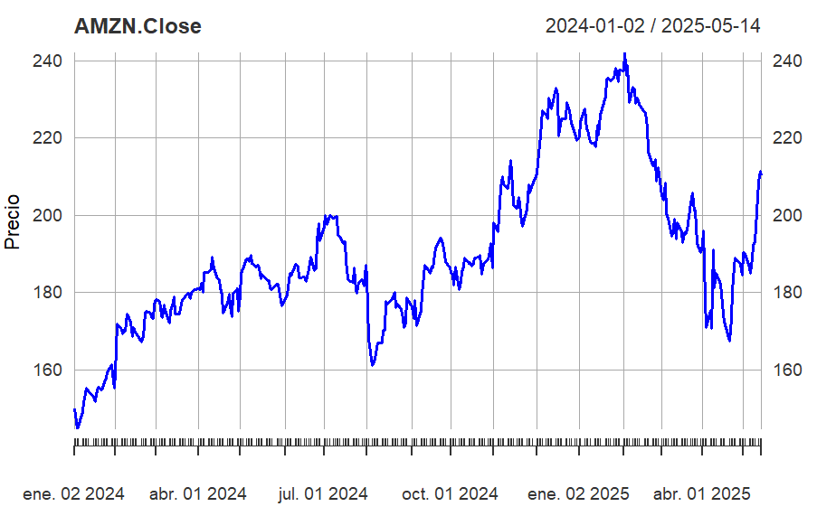

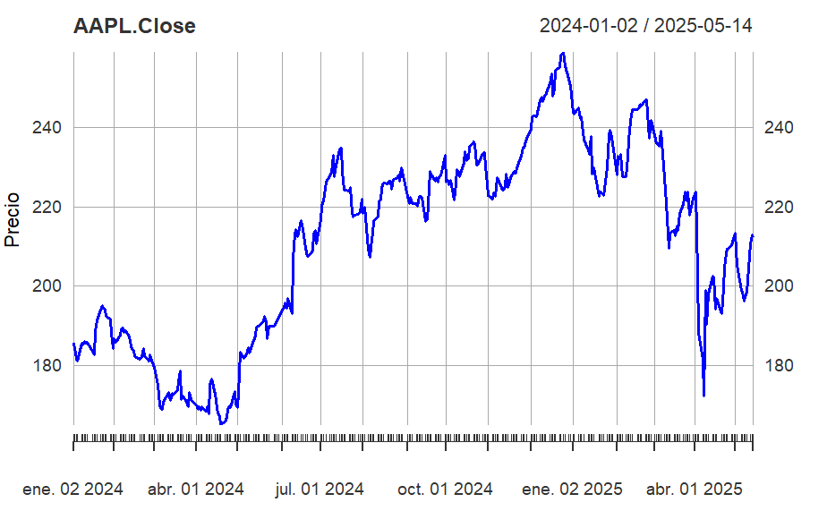

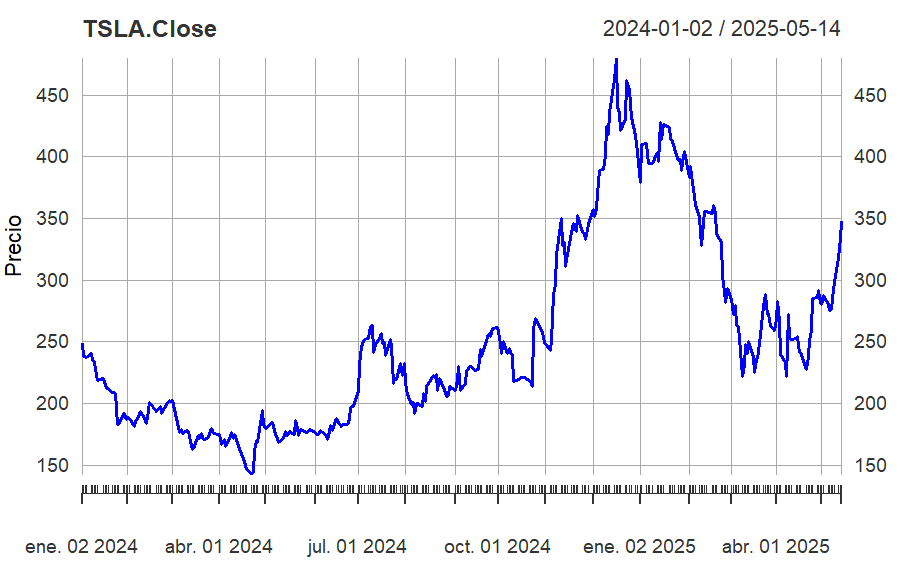

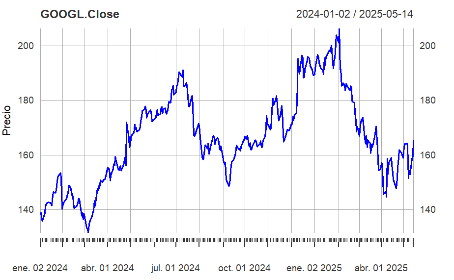

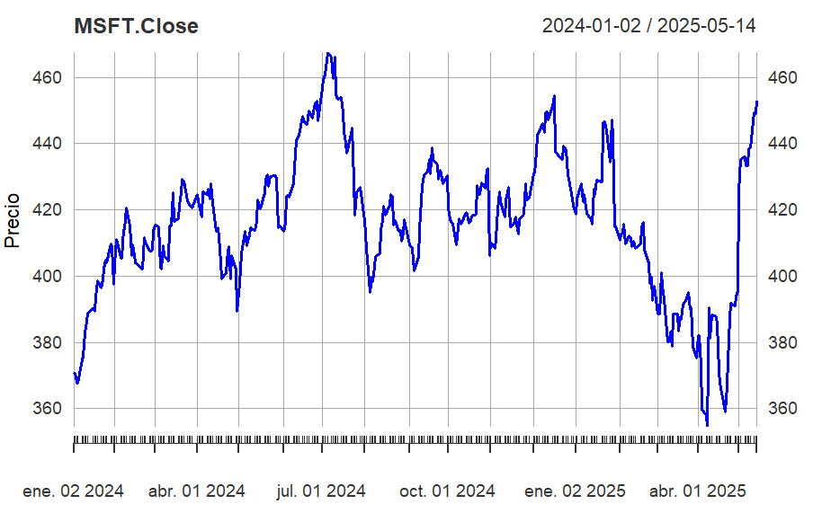

```r
for (i in 1:length(nombre_empresas)) {
  print(
    plot(tabla_precios[,i],
       type = 'l',
       main = nombre_empresas[i],
       xlab = 'fecha',
       ylab = "Precio",
       col = "blue")
  )
}
```

*-Hacemos lo mismo para las graficas de rendimiento.*

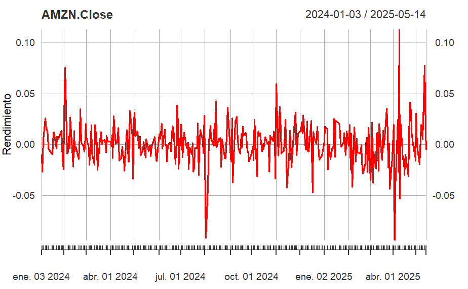

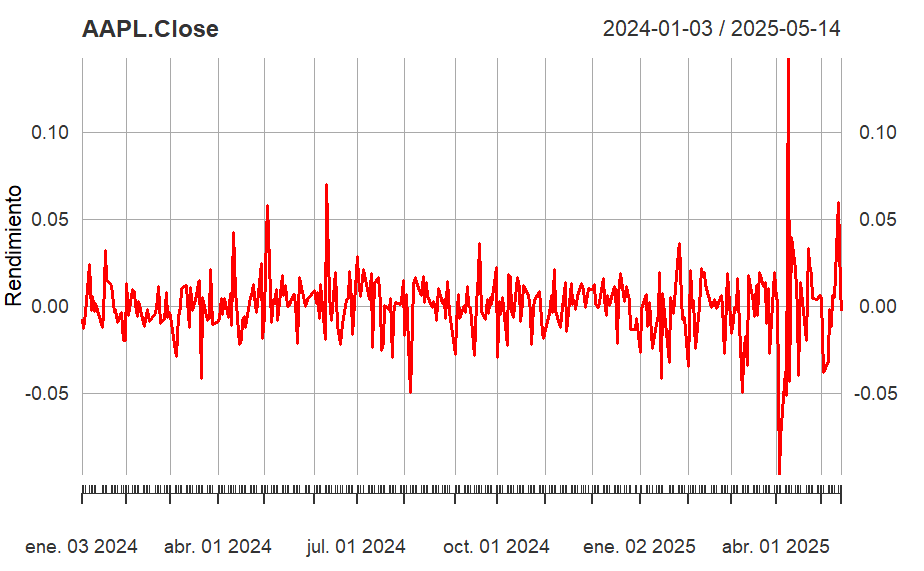

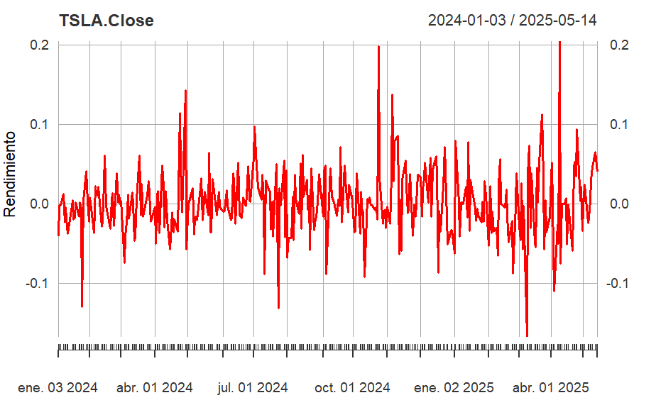

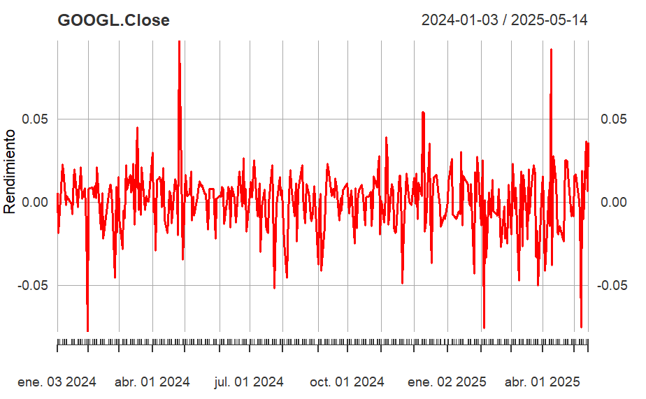

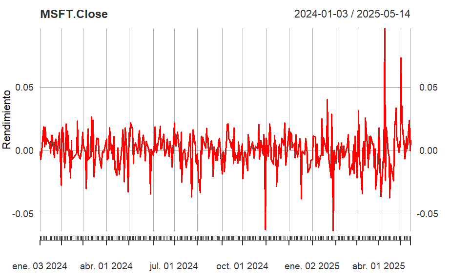

```r
for (i in 1:length(nombre_empresas)) {
  print(
    plot(tabla_rendimientos[,i],
       type = 'l',
       main = nombre_empresas[i],
       xlab = 'fecha',
       ylab = "Rendimiento",
       col = "red")
  )
}
```

7. ¿Que funcion se utiliza para construir la matriz de varianza-covarianza a partir de los rendimientos diarios en R? Genera y muestra la matriz.

-Para construir la matriz de varianza - covarianza a partir de los rendimientos rendimientos diarios logartimicos se utiliza la siguiente funcion:

```r
cov()
```

-Esta funcion calcula la covarianza entre las columnas de un data frame o matriz numerica.

*-Utilizamos la funcion con nuestro Dataframe de rendimientos.*

```r
matriz_covarianza <- cov(tabla_rendimientos)
```

*-Llamamos a la matriz para verificar.*

```r
matriz_covarianza
```

```
              AMZN.Close   AAPL.Close   TSLA.Close  GOOGL.Close
AMZN.Close  0.0004163065 0.0002083349 0.0004219040 0.0002481365
AAPL.Close  0.0002083349 0.0003635030 0.0003863377 0.0001800131
TSLA.Close  0.0004219040 0.0003863377 0.0018217998 0.0003632384
GOOGL.Close 0.0002481365 0.0001800131 0.0003632384 0.0003881487
MSFT.Close  0.0002230630 0.0001595198 0.0002873795 0.0001790449
              MSFT.Close
AMZN.Close  0.0002230630
AAPL.Close  0.0001595198
TSLA.Close  0.0002873795
GOOGL.Close 0.0001790449
MSFT.Close  0.0002320626
```

8. ¿Como se interpreta la varianza de los rendimientos diarios de una accion en terminos de volatilidad?

La varianza en los rendimientos diarios de nuestras acciones, nos indica que tanto es que fluctuan sus rendimientos respecto al promedio, en terminos de acciones y esta directamente relacoinada con la volatilidad de la misma. La varianza mide la dispersion de los rendimientos, por ejemplo: si los rendimientos diarios cambiaran mucho de un dia a otro, la varianza sera alta, una varianza alta implica un riesgo alto, aunque la probabilidad de ganancias grandes aumenta, la de perdidas tambien lo hace.

9. ¿C ́omo se interpreta la covarianza entre dos acciones dentro de la matriz? ¿Qu ́e significa una covarianza positiva o negativa?

La covarianza entre dos acciones en la matriz de varianza-covarianza mide como es que se mueve junta la rentabilidad diaria de esas acciones, una covarianza positiva indica que, cuando una accion sube, la otra tiende tambien a subir, y cuando una baja, la otra tambien tiende a bajar, se mueven en la misma direccion. Una covarianza negativa indica que cuando una accion sube, la otra baja y viceversa, lo que significa que se mueven en direciones opuestas.

10. Analiza e interpreta los resultados obtenidos de la matriz: ¿que accion es mas volatil?, ¿que pares de acciones tienen la mayor o menor covarianza?

Como se comento con anterioridad, la varianza nos dira la volatilidad de un activo, en nuestra matriz de varianza-covarianza, nuestras varianzas son las diagonales, siento TESLA (TSLA) la que tiene una mayor varianza y por ende, una mayor volatilidad con un *0.0018217998* de varianza y siendo MICROSOFT (MSFT) la de menor varianza y volatilidad con un *0.0002320626*, en cuanto a la covarianza, TESLA (TSLA) y AMAZON (AMZN) son los que tienen una mayor covarianza, lo que significa que se mueven mas en sincronia una con la otra con un *0.0004219040* y el par de acciones que tiene la menor covarianza son MICROSOFT (MSFT) y APPEL (AAPL) con un 0.0001595198 de covarianza, aunque no es una covarianza negativa, su movimiento no es tan fuerte como el de TSLA Y AMZN.